# data_analysis_russian_propaganda

## Homework #4. Exploratory Data Analysis

## Homework #5. Behaviour exploration improvement

#### Author: `<Zlata> <Karbovska>`

#### Total time spent on h/w. Part 2 (in minutes): `<679>`

#### Total time spent on h/w 5. Part 3 (in minutes): `<144>`

## For hw 5

I extended the scope of analysis and dived deeper into key aspects of the dataset. I analyzed the yearly trends of posts containing specific substrings like "украи," "бандер," and "неонац," created visualizations such as bigram frequency charts and circular diagrams, and identified the most viewed posts containing 'укра' for each year. These enhancements provided a more comprehensive understanding of the dataset, highlighting significant narratives and patterns in the data over time.

```
Summarizing: added 6 more related questions.
```

To see my new work, please, go via this link: Go to Section 1

```python
import pandas as pd
import numpy as np
import matplotlib.pyplot as plt
import matplotlib.cm as cm
import glob
import seaborn as sns
from collections import Counter
import re
import sys
import tabulate
```

```python
data = pd.read_csv(
    "C:/Users/Zlata.DESKTOP-S3VC9UU/Desktop/uni/CSS/4_15/data/data.csv")
```

```python
# global function to make variable appear bold
def make_bold(var):
    return f"\033[1m{var}\033[0m"
```

```python
from PIL import Image, ImageEnhance


def adjust_saturation(color, factor):
    image = Image.new("RGB", (1, 1), color)
    enhancer = ImageEnhance.Color(image)
    adjusted_image = enhancer.enhance(factor)
    # Extract the adjusted RGB color
    adjusted_color = adjusted_image.getpixel((0, 0))
    # Convert RGB to HEX
    return "#{:02x}{:02x}{:02x}".format(*adjusted_color)
```

```python
data['date'] = pd.to_datetime(data['date'], errors='coerce')

# Check the minimum and maximum dates
min_date = data['date'].min()
max_date = data['date'].max()

print(f"The date range in the CSV file is from {
      make_bold(min_date)} to {make_bold(max_date)}.")
```

[output not shown]

```python
import sqlite3

# Create a new SQLite database
conn = sqlite3.connect("data.db")
data.to_sql("data", conn, if_exists="replace", index=False)
conn.close()
```

```python
import sqlite3

conn = sqlite3.connect("data.db")

query = "SELECT MIN(date), MAX(date) FROM data"
min_date, max_date = conn.execute(query).fetchone()

print(f"The date range in the SQLite database is from {
      make_bold(min_date)} to {make_bold(max_date)}.")

conn.close()
```

```
The date range in the SQLite database is from 2015-09-22 11:53:32+00:00 to 2022-12-26 10:59:50+00:00.
```

```python
data_sorted = data.sort_values(by='date')
data_sorted.head()
```

|  | Unnamed: 0 | id | date | views | reactions | to_id | fwd_from | message | type | duration | ... | frw_from_name | msg_entity | datetime | message_len | reactions_dict | reactions_num | _from_id | _to_id | sensitive-topic | toxicity |
| --- | --- | --- | --- | --- | --- | --- | --- | --- | --- | --- | --- | --- | --- | --- | --- | --- | --- | --- | --- | --- | --- |
| 1195485 | 49182 | 1.0 | 2015-09-22 11:53:32+00:00 | NaN | NaN | PeerChannel(channel_id=1003313758) | NaN | NaN | text | NaN | ... | NaN | NaN | 2015-09-22 11:53:32+00:00 | 0 | [] | 0 | NaN | 1003313758 | none | neutral |
| 5282296 | 7624 | 1.0 | 2015-09-22 14:46:48+00:00 | NaN | NaN | PeerChannel(channel_id=1005684212) | NaN | NaN | text | NaN | ... | NaN | NaN | 2015-09-22 14:46:48+00:00 | 0 | [] | 0 | NaN | 1005684212 | none | neutral |
| 5282295 | 7623 | 9.0 | 2015-09-22 16:12:02+00:00 | 1841.0 | MessageReactions(results=[ReactionCount(reacti... | PeerChannel(channel_id=1005684212) | NaN | 😛 | sticker | NaN | ... | NaN | NaN | 2015-09-22 16:12:02+00:00 | 1 | [{"reaction": "\ud83d\udc4d", "count": 8, "cho... | 12 | NaN | 1005684212 | none | neutral |
| 7768627 | 13628 | 1.0 | 2015-09-22 21:17:51+00:00 | NaN | NaN | PeerChannel(channel_id=1004504016) | NaN | NaN | text | NaN | ... | NaN | NaN | 2015-09-22 21:17:51+00:00 | 0 | [] | 0 | NaN | 1004504016 | none | neutral |
| 7768626 | 13627 | 2.0 | 2015-09-22 21:19:46+00:00 | 355.0 | MessageReactions(results=[ReactionCount(reacti... | PeerChannel(channel_id=1004504016) | NaN | Тестирую какую-то новую приблуду телеграма- пу... | text | NaN | ... | NaN | NaN | 2015-09-22 21:19:46+00:00 | 60 | [{"reaction": "\ud83d\udc4f", "count": 5, "cho... | 6 | NaN | 1004504016 | online_crime | neutral |

5 rows × 22 columns

Questions I am aimed to get answers for:

---- ADDITIONAL QUESTIONS CREATED FOR HW 5 (related to q.16th): ----

1. Top 20 Bigrams in Posts Containing 'украи' in January each year
2. In the diagram in task 16 we can see the Number of posts including 'украи' in January each year. So in this task I will show the most viewed Post data (text, views and date) for each Year containing 'украи'.
3. Show the number of occurincies of part 'неонац' in posts each year
4. Show the occurincies of part 'бандер' in posts through years
5. Show the occurincies of part 'украи' in posts through years
6. Depict in circular diagram number of 'укра', 'бандер' and 'неонац' part through all years in posts' text. What is prevailing?

---- end of additional questions ----

ANSWER THE QUSTIONS

1. Count how many different channels dataset has

```python
unique_channels = data['channel'].nunique()

print(f"The dataset has {make_bold(unique_channels)} different channels.")
```

```
The dataset has 299 different channels.
```

2. At which year channels published the most posts?

```
The year with the most posts is 2022 with 3374025 posts.
Number of posts per year:
year
2015       5055
2016      93804
2017     334932
2018     495335
2019     740133
2020    1351500
2021    1713909
2022    3374025
Name: count, dtype: int64
```

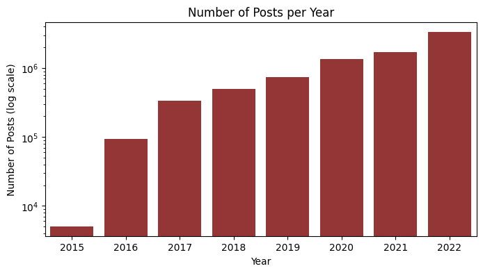

```python
data['datetime'] = pd.to_datetime(data['date'])
data['year'] = data['datetime'].dt.year
posts_per_year = data['year'].value_counts().sort_index()

most_posts_year = posts_per_year.idxmax()
most_posts_count = posts_per_year.max()

print(f"The year with the most posts is {
      make_bold(most_posts_year)} with {make_bold(most_posts_count)} posts.")
print("Number of posts per year:")
print(posts_per_year)

red = (255, 0, 0)
# Use a logarithmic scale for the y-axis if values are very large
plt.figure(figsize=(8, 4))
sns.barplot(x=posts_per_year.index, y=posts_per_year.values, color=adjust_saturation(red, 0.5))
plt.title("Number of Posts per Year")
plt.xlabel("Year")
plt.ylabel("Number of Posts (log scale)")
plt.yscale('log')  # Set y-axis to logarithmic scale

plt.show()
```

3. Which topic gathered the most views? (from sensitive-topic column)

```python
postWithMostViews = data['views'].max()
postID = data['views'].idxmax()
postText = data.loc[postID, 'message']
postTopic = data.loc[postID, 'sensitive-topic']
postYear = data.loc[postID, 'year']

print("The post's topic with the most views is:")
print(f"ID:{make_bold(postID)}, YEAR: {make_bold(postYear)}, \nTEXT: {
      postText}, VIEWS: {make_bold(postWithMostViews)}, TOPIC: {make_bold(postTopic)}.")
print("-"*50)
```

```
The post's topic with the most views is:
ID:4446208, YEAR: 2022,
TEXT: «Мы встретим рассвет» — новый клип в поддержку наших защитников.

Знаем, как сейчас тяжело нашим ребятам, которые каждый день и ночь проявляют невероятную стойкость, мужество и крепость духа.
Вы - воины чести и правды. Такими вас знают, боятся и ценят.

Мы с вами, ребята! И мы обязательно вместе встретим рассвет на РОДНОЙ ЗЕМЛЕ!

Архангел Спецназа. Подписаться., VIEWS: 10318833.0, TOPIC: politics.
--------------------------------------------------
```

4. What's the average of views for neutral toxicity?

```python
neutral_toxicity_posts = data[data['toxicity'] == 'neutral']

average_views_neutral = neutral_toxicity_posts['views'].mean()

print(f"The average number of views for posts with neutral toxicity is {
      make_bold(f'{average_views_neutral:.2f}')}")
```

```
The average number of views for posts with neutral toxicity is 51935.34
```

5. What's the average of views for toxic toxicity?

```python
neutral_toxicity_posts = data[data['toxicity'] == 'toxic']

average_views_toxic = neutral_toxicity_posts['views'].mean()

print(f"The average number of views for posts with toxic toxicity is {
      make_bold(f'{average_views_toxic:.2f}')}")
```

```
The average number of views for posts with toxic toxicity is 65545.90
```

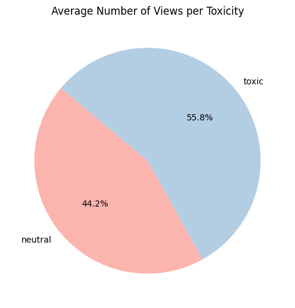

```python
# COMPARE TWO ON VISUALIZATION
unique_toxicities = data['toxicity'].unique()
average_views = data.groupby('toxicity')['views'].mean()

# Plot a pie chart
plt.figure(figsize=(8, 6))
colors = plt.get_cmap('Pastel1').colors

plt.pie(average_views.values, labels=average_views.index,
        autopct='%1.1f%%', startangle=140, colors=colors[:len(average_views)])
plt.title("Average Number of Views per Toxicity")
plt.show()
```

6. Which type of post was the most frequent? (text, audio, video)

```
postTypes:type
photo      3371907
text       3210160
video      1308377
voice         7649
sticker       5986
Name: count, dtype: int64

The most frequent type of post is photo.
```

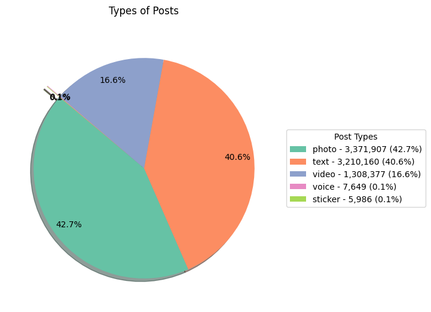

```python
postsTypes = data['type'].value_counts()
numberOfPosts = postsTypes.idxmax()
print(f"postTypes:{postsTypes}")
print(f"\nThe most frequent type of post is {make_bold(numberOfPosts)}.")

# VISUALIZATION
post_types = list(postsTypes.index)
post_values = list(postsTypes.values)

plt.figure(figsize=(8, 6))
colors = plt.get_cmap('Set2').colors
explode = [0.15 if post_type in ['sticker', 'voice']
           else 0 for post_type in post_types]

# Create the pie chart without labels on the chart
wedges, _, autotexts = plt.pie(
    post_values,
    labels=[None] * len(post_types),  # No labels directly on the pie chart
    autopct='%1.1f%%',
    startangle=140,
    colors=colors[:len(post_types)],
    explode=explode,
    shadow=True,
    pctdistance=0.85,
)

# Add percentage text on wedges
for autotext in autotexts:
    autotext.set_fontsize(10)
    autotext.set_color("black")

# Customize the legend to include both counts and percentages
total = sum(post_values)
legend_labels = [
    f"{post_type} - {value:,} ({value / total:.1%})" for post_type, value in postsTypes.items()]
plt.legend(wedges, legend_labels, title="Post Types",
           loc="center left", bbox_to_anchor=(1, 0, 0.5, 1))

# Add title
plt.title("Types of Posts", pad=20)

plt.show()
```

7. What's the average post length?

```
The average length of a post is 417.50 characters.
```

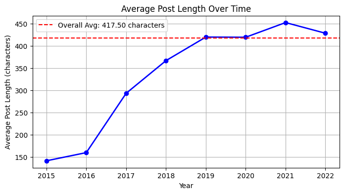

```python
averPostLength = data['message'].str.len().mean()
print(f"The average length of a post is {
      make_bold(f'{averPostLength:.2f}')} characters.")

# VISUALIZATION
# visualize the distribution of post lengths

# Calculate the average post length by year
data['year'] = data['datetime'].dt.year
average_length_per_year = data.groupby(
    'year')['message'].apply(lambda x: x.str.len().mean())

plt.figure(figsize=(8, 4))
plt.plot(average_length_per_year.index, average_length_per_year.values,
         marker='o', color='b', linestyle='-', linewidth=2)
plt.axhline(y=averPostLength, color='r', linestyle='--',
            label=f"Overall Avg: {averPostLength:.2f} characters")
plt.title("Average Post Length Over Time")
plt.xlabel("Year")
plt.ylabel("Average Post Length (characters)")
plt.legend()
plt.grid(True)
plt.show()
```

8. Which post got the most views?

```python
postID = data['views'].idxmax()

postWithMostViews = data.loc[postID]
postId = postWithMostViews['id']
postViews = postWithMostViews['views']
postDate= postWithMostViews['date']
print(f"The post with the most views is: ID:{
      make_bold(postId)}, VIEWS: {make_bold(postViews)}")
print("DATE:", make_bold(postDate))
print(postWithMostViews['message'])
```

```
The post with the most views is: ID:5768.0, VIEWS: 10318833.0
DATE: 2022-10-13 21:05:10+00:00
«Мы встретим рассвет» — новый клип в поддержку наших защитников.

Знаем, как сейчас тяжело нашим ребятам, которые каждый день и ночь проявляют невероятную стойкость, мужество и крепость духа.
Вы - воины чести и правды. Такими вас знают, боятся и ценят.

Мы с вами, ребята! И мы обязательно вместе встретим рассвет на РОДНОЙ ЗЕМЛЕ!

Архангел Спецназа. Подписаться.
```

9. Which post got the least views?

```python
postID = data['views'].idxmin()

postWithLeastViews = data.loc[postID]
postId = postWithLeastViews['id']
postViews = postWithLeastViews['views']
postYear = postWithLeastViews['year']
print(f"The post with the least views is: ID:{
      make_bold(postId)}, VIEWS: {make_bold(postViews)}")
print("YEAR:", make_bold(postYear))
print(postWithLeastViews['message'])
```

```
The post with the least views is: ID:11676.0, VIEWS: 1.0
YEAR: 2019
В Польше объяснили отказ пригласить Россию на годовщину Второй мировой.

‘Представителей России не пригласили на торжества по случаю 80-й годовщины начала Второй мировой войны из-за отсутствия заинтересованности России в сохранении ‘духа исторической правды’- замминистра иностранных дел Шинковский заявил, что Польша меняет свой подход к историческим вопросам. В качестве …

Ну то, что переписывать историю- плохо,- в Польше, наверное, слышали. Но гордиться этим, ребята, - вообще какая-то дурь.
```

10. What was the prevailing toxicity (neutral/toxic) for the 24th February?

```
For the 24th of February, the prevailing toxicity was neutral.
```

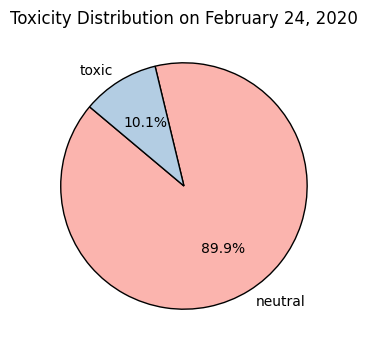

```python
data['date'] = pd.to_datetime(data['date'])

feb_24_data = data[data['date'].dt.date == pd.to_datetime('2020-02-24').date()]

prevailToxicity = feb_24_data['toxicity'].value_counts().idxmax()

print(f"For the 24th of February, the prevailing toxicity was {
      make_bold(prevailToxicity)}.")

# VISUALIZATION
toxicity_counts = feb_24_data['toxicity'].value_counts()

plt.figure(figsize=(6, 4))
colors = plt.get_cmap('Pastel1').colors
plt.pie(toxicity_counts.values, labels=toxicity_counts.index,
        autopct='%1.1f%%', startangle=140, colors=colors[:len(toxicity_counts)],
        wedgeprops={'edgecolor': 'black'})  # Add a border for clarity

plt.title("Toxicity Distribution on February 24, 2020")
plt.show()
```

11. Which toxicity for the posts was superior? (take all toxicities and find the one, that was used the most)

```python
prevailingToxicity = data['toxicity'].value_counts().idxmax()
print(f"The most frequent toxicity in the dataset is {
      make_bold(prevailingToxicity)}.")
```

```
The most frequent toxicity in the dataset is neutral.
```

12. Which toxicity for the posts was inferior?

```python
leastFrequentToxicity = data['toxicity'].value_counts().idxmin()
print(f"The least frequent toxicity in the dataset is {
      make_bold(leastFrequentToxicity)}.")
# - _ -
```

```
The least frequent toxicity in the dataset is toxic.
```

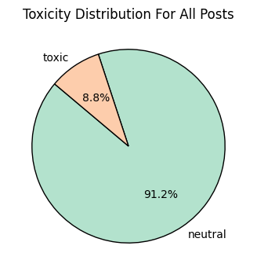

```python
# VISUALIZATION
toxicity_counts_general = data['toxicity'].value_counts()

plt.figure(figsize=(6, 4))
colors = plt.get_cmap('Pastel2').colors
plt.pie(toxicity_counts_general.values, labels=toxicity_counts_general.index,
        autopct='%1.1f%%', startangle=140, colors=colors[:len(toxicity_counts_general)],
        wedgeprops={'edgecolor': 'black'})

plt.title("Toxicity Distribution For All Posts")
plt.show()
```

13. Which topic (sensitive-topic) had the shortest post?

```python
shortPostIndex = data['message'].str.len().idxmin()
shortPostTopic = data.loc[shortPostIndex, 'sensitive-topic']
postText = data.loc[shortPostIndex, 'message']

print(f"The topic of the shortest post is: {
      shortPostTopic}. Its text is {postText}.")
```

```
The topic of the shortest post is: none. Its text is 😢.
```

14. Which topic (sensitive-topic) had the longest post?

```python
longestPostIndex = data['message'].str.len().idxmax()
longestPostTopic = data.loc[longestPostIndex, 'sensitive-topic']
longestPostText = data.loc[longestPostIndex, 'message']

print(f"The topic of the longest post is: {
      make_bold(longestPostTopic)}.")
print(f"Its length is {make_bold(len(longestPostText))} characters.")
print(f"Its text is: {longestPostText}.")

def truncate_text(text, max_length=200):
    return (text[:max_length] + '...') if len(text) > max_length else text

truncated_text = truncate_text(longestPostText)

print(f"The topic of the longest post is: {
      make_bold(truncated_text)}.")
print(f"Its length is {make_bold(len(truncated_text))} characters.")
print(f"Its text is: {truncated_text}.")
```

```
The topic of the longest post is: politics.
Its length is 4096 characters.
Its text is: Главный редактор ИА Regnum, писатель, журналист, член СПЧ Марина Ахмедова @Marinaslovo

Вчера на встрече СПЧ с президентом наш член Маковецкая сложно и монотонно говорила о важном — о работе российских НКО. Президент внимательно слушал, поигрывая большой скрепкой на столе. «Цык-цык, — издавала звук скрепка, — цык-цык». И голос нашего члена, и звук скрепки вводили в умиротворённое состо…

Путин перестал щёлкать скрепкой.

— Сто раз же уже говорили, что Россия не собирается, — пробурчала я в сторону члена совета Ашманова, сидевшего со мной рядом. Имела я в виду Лаврова и Пескова, а также то, как иностранные «свободные» СМИ постоянно раскручивают ядерную истерию и России приходится периодически повторять: «Мы не планир…

Тут наш член Маковецкая попросила Путина сделать личное заявление, что Россия ни при каких обстоятельствах не применит ядерное оружие, и я поняла, что моя догадка о всемирной психотерапии подтверждается. И сейчас Путин скажет: «Конечно, ни при каких…»
Но Путин сказал: «Вы правы, такая угроза нарастает, чего здесь греха таить».

Все подобрались. Я безнадёжно посмотрела на скрепку, лежавшую на президентском столе. Теперь Путин не обращал на неё внимания. Не то чтобы я жила с постоянным страхом ядерной войны. Во мне такого страха нет — почему-то есть уверенность, что её не будет. Но как-то в ноябре я сидела на диване в деревя…

— По поводу того, что Россия ни при каких обстоятельствах не применит первой, — продолжил президент. — Но если не применит первой ни при каких обстоятельствах, значит, и второй тоже не применит, потому что возможности применения в случае нанесения ядерного удара по нашей территории сильно ограниченн…

После этих слов я вспомнила мысль, которая ко мне пришла в том деревянном доме сразу после вспышки и испытанной пронзительной жалости. Но если эти дети, эти кошки, эти берёзы и эта земля исчезнут в результате атаки на нас, то кому нужен такой мир?

Путин снова взялся за скрепку и дальше говорил, что американское тактическое оружие расположено на европейской территории, а мы же, напротив, своё никому не передавали и не передаём, но, естественно, своих союзников будем защищать всеми имеющимися у нас способами. «В этом месте союзники должны успок…

— Разве мы говорили о возможности применения? — продолжал Путин. — Нет… Мы с ума не сошли — мы отдаём себе отчёт в том, что такое ядерное оружие. Эти средства у нас есть, и они в более продвинутом и более современном виде находятся, чем у какой-либо другой страны.

«Вот и хорошо, — подумала я. — И не лезьте к нашим детям, кошкам, домам, берёзам. У нас самое современное оружие».

Дальше Путин говорил, что ядерное оружие для нас — не провоцирующий, а сдерживающий фактор. И мир — союзники, противники и просто взволнованные люди — укладывался на кушетку, ровно дышал. «Цык-цык, — издавала скрепка. — Цык-цык».

Точка зрения автора может не совпадать с позицией редакции.

@rt_special.
The topic of the longest post is: Главный редактор ИА Regnum, писатель, журналист, член СПЧ Марина Ахмедова @Marinaslovo

Вчера на встрече СПЧ с президентом наш член Маковецкая сложно и монотонно говорила о важном — о работе российски....
Its length is 203 characters.
Its text is: Главный редактор ИА Regnum, писатель, журналист, член СПЧ Марина Ахмедова @Marinaslovo

Вчера на встрече СПЧ с президентом наш член Маковецкая сложно и монотонно говорила о важном — о работе российски....
```

```python
data['date'] = pd.to_datetime(data['date'])
feb_24_data = data[data['date'].dt.date == pd.to_datetime('2020-02-24').date()]
mostViewedPostId = feb_24_data['views'].idxmax()


mostViewedPostDateTime = feb_24_data.loc[mostViewedPostId, 'date']
mostViewedPostHour = mostViewedPostDateTime.strftime("%H:%M:%S")

mostViewedPostText = feb_24_data.loc[mostViewedPostId, 'message']
mostViewedPostViews = feb_24_data.loc[mostViewedPostId, 'views']

print(f"The most viewed post for 24.02.2022, HOUR: {make_bold(mostViewedPostHour)}, \nID: {make_bold(mostViewedPostId)}, \ntext: {
      mostViewedPostText}, \nVIEWS: {make_bold(mostViewedPostViews)}.")
# - _ -
```

```
The most viewed post for 24.02.2022, HOUR: 09:37:10,
ID: 490098,
text: В Тольятти 11-летние хоккеисты устроили драку на турнире кубка федерации.

К махачу между «Ладой» и «Волгарем», который изначально возник между игроками, подключились и вратари, и даже запасные.

Трус не играет в хоккей.,
VIEWS: 341814.0.
```

16. How many posts included "украи" part in January each year? (2015-2022)

```
Number of posts including 'украи' in January 2022: 17960
Number of posts including 'украи' in January 2021: 3355
Number of posts including 'украи' in January 2020: 5038
Number of posts including 'украи' in January 2019: 1901
Number of posts including 'украи' in January 2018: 975
Number of posts including 'украи' in January 2017: 311
Number of posts including 'украи' in January 2016: 58
Number of posts including 'украи' in January 2015: 0
```

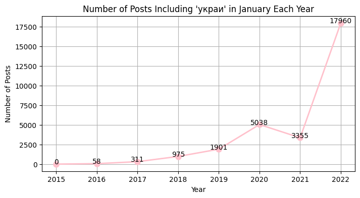

```python
data['date'] = pd.to_datetime(data['date'])


def count_posts_including_ukra(year):
    january_posts = data[(data['date'].dt.year == year)
                         & (data['date'].dt.month == 1)]

    count = january_posts['message'].str.contains(
        "украи", case=False, na=False).sum()

    return count


unique_years = data['date'].dt.year.unique()

for year in unique_years:
    count = count_posts_including_ukra(year)
    print(f"Number of posts including 'украи' in January {year}: {count}")

# VISUALIZATION
ukra_counts = {year: count_posts_including_ukra(year) for year in unique_years}

years = list(ukra_counts.keys())
counts = list(ukra_counts.values())

plt.figure(figsize=(8, 4))
plt.plot(years, counts, marker='o', color='pink',
         linestyle='-', linewidth=2, markersize=8)
plt.title("Number of Posts Including 'украи' in January Each Year")
plt.xlabel("Year")
plt.ylabel("Number of Posts")
plt.grid(True)

# Annotate each point with the count
for i, count in enumerate(counts):
    plt.text(years[i], counts[i] + 5, str(count), ha='center', color='black')

plt.show()
```

## Section-1: ADDITIONS to task 16 for hw 5

16.1. In this task I created and analyzed biagrams for word pairs for post 16 containing 'ukra' in January each year. Additionaly, create a digram that illustrates 20 the most frequent bigrams that appear in posts containing the substring "украи". Each bar represents a bigram, and the height of the bar corresponds to the number of times that bigram appears in the filtered dataset.

```
#Task: Top 20 Bigrams in Posts Containing 'украи' in January each year
```

```
Total number of bigrams: 1077396
```

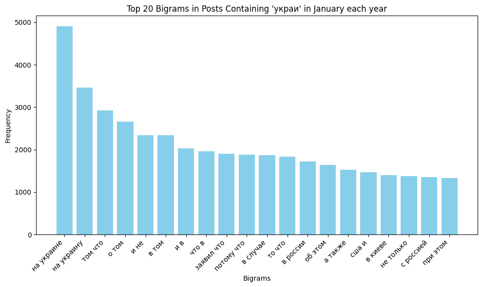

```python
data['date'] = pd.to_datetime(data['date'])
january_posts = data[(data['date'].dt.month == 1) &
                     data['message'].str.contains('украи', case=False, na=False)].copy()


def preprocess_text(text):
    # Remove punctuation, lowercase
    text = re.sub(r'[^\w\s]', '', text.lower())
    return text.split()  # Tokenize into words


january_posts.loc[:, 'cleaned_message'] = january_posts['message'].apply(
    preprocess_text)


def generate_bigrams(tokens):
    return list(zip(tokens, tokens[1:]))


all_bigrams = []
for tokens in january_posts['cleaned_message']:
    all_bigrams.extend(generate_bigrams(tokens))

bigram_counts = Counter(all_bigrams)
print("Total number of bigrams:", len(bigram_counts))

# Convert to DataFrame for analysis
bigram_df = pd.DataFrame(bigram_counts.items(), columns=[
                         'Bigram', 'Frequency']).sort_values(by='Frequency', ascending=False)

# Step 4: Visualize top 20 bigrams
top_bigrams = bigram_df.head(20)
plt.figure(figsize=(10, 6))
plt.bar([' '.join(bigram) for bigram in top_bigrams['Bigram']],
        top_bigrams['Frequency'], color='skyblue')
plt.title("Top 20 Bigrams in Posts Containing 'украи' in January each year")
plt.xlabel("Bigrams")
plt.ylabel("Frequency")
plt.xticks(rotation=45, ha='right')
plt.tight_layout()
plt.show()
```

16.2. In the diagram in task 16 we can see the Number of posts including 'украи' in January each year. So in this task I will show the most viewed Post data (text, views and date) for each Year containing 'украи'.

```python
data['date'] = pd.to_datetime(data['date'])
ukrainian_posts = data[data['message'].str.contains(
    'украи', case=False, na=False)].copy()

# Modify 'year' explicitly
ukrainian_posts.loc[:, 'year'] = ukrainian_posts['date'].dt.year

most_viewed_per_year = ukrainian_posts.loc[
    ukrainian_posts.groupby('year')['views'].idxmax()
]


def shorten_text(text, limit=360, indent_limit=130):
    if len(text) > limit:
        text = text[:limit] + "..."
    if len(text) > indent_limit:
        lines = []
        for i in range(0, len(text), indent_limit):
            lines.append(text[i:i+indent_limit])
        return '\n'.join(lines)
    return text


most_viewed_per_year['message'] = most_viewed_per_year['message'].apply(
    shorten_text
)


def human_readable_number(num):
    if num >= 1e6:
        return f"{num/1e6:.2f}M"
    elif num >= 1e3:
        return f"{num/1e3:.2f}K"
    return str(int(num))


most_viewed_per_year['views'] = most_viewed_per_year['views'].apply(
    human_readable_number
)

# Select relevant columns
most_viewed_per_year_result = most_viewed_per_year[
    ['date', 'message', 'views']
]

print(tabulate.tabulate(most_viewed_per_year_result,
      headers="keys", tablefmt="fancy_grid"))
```

```
╒═════════╤═══════════════════════════╤════════════════════════════════════════════════════════════════════════════════════════════════════════════════════════════════════╤═════════╕
│         │ date                      │ message                                                                                                                            │ views   │
╞═════════╪═══════════════════════════╪════════════════════════════════════════════════════════════════════════════════════════════════════════════════════════════════════╪═════════╡
│ 7175766 │ 2015-09-23 10:11:11+00:00 │ Не люблю украинцев                                                                                                                 │ 10.14K  │
├─────────┼───────────────────────────┼────────────────────────────────────────────────────────────────────────────────────────────────────────────────────────────────────┼─────────┤
│ 7585175 │ 2016-12-22 07:46:26+00:00 │ Я не знаю, что сказать по поводу убийства российского посла в Турции. Не знаю, как оно отразится на всей вашей геополитике. Не зна │ 71.90K  │
│         │                           │ ю, что написать, кроме того, что убийство – это плохо.  И, судя по реакции официального МИДа, постящей мемасики, которые, видимо,  │         │
│         │                           │ должны как-то выражать государственную позицию в связи со смертью посла, я не один такой, и она тоже...                            │         │
├─────────┼───────────────────────────┼────────────────────────────────────────────────────────────────────────────────────────────────────────────────────────────────────┼─────────┤
│ 7585050 │ 2017-07-10 15:47:34+00:00 │ Фантастические мрази. Ещё совсем недавно патриотическая общественность гневно негодовала и разнообразно осуждала решение украински │ 225.15K │
│         │                           │ х властей не пустить на Евровидение певицу Юлию Самойлову. Хохлы, где ваша человечность? – кричали люди, бросившие девушку в инвал │         │
│         │                           │ идной коляске в пекло политической борьбы. Но вот Антон Мамаев, обездвиженный инвалид, приговорённый...                            │         │
├─────────┼───────────────────────────┼────────────────────────────────────────────────────────────────────────────────────────────────────────────────────────────────────┼─────────┤
│ 7584779 │ 2018-04-24 05:42:51+00:00 │ Уже, наверное, можно поздравить народ Армении с мирной и ненасильственной сменой власти, к которой привели многотысячные протесты, │ 307.57K │
│         │                           │  а всем нам, живущим в России, стоит приготовиться к новой порции пиздеца. Потому что сейчас все параноики во власти, больше всего │         │
│         │                           │  боящиеся увидеть людей на улицах, начнут писать докладные записки, где будут перечислять, что конкр...                            │         │
├─────────┼───────────────────────────┼────────────────────────────────────────────────────────────────────────────────────────────────────────────────────────────────────┼─────────┤
│  492079 │ 2019-10-19 14:34:23+00:00 │ "Раньше не знал, кто такой Зеленский"                                                                                              │ 436.07K │
│         │                           │                                                                                                                                    │         │
│         │                           │ Двойник украинского президента из столичной подземки рассказал нам о своей жизни. Его часто                                        │         │
│         │                           │  узнают на улице, а на работе в шутку называют Зеленским. Мечты у Умида самые простые: достойно жить со своей семьёй. А звёздной к │         │
│         │                           │ опии мужчина желает здоровья (и в случае чего готов подменить на съёмках).                                                         │         │
├─────────┼───────────────────────────┼────────────────────────────────────────────────────────────────────────────────────────────────────────────────────────────────────┼─────────┤
│  490824 │ 2020-01-08 03:55:35+00:00 │ Момент падения самолёта "Украинских авиалиний" под Тегераном. Видео опубликовали очевидцы, по их словам, на видео — тот самый Boei │ 914.02K │
```

[output cut: 12 more lines]

16.3. Show the number of occurincies of part 'неонац' in posts each year

```
Number of occurrences of 'неонац' for each year:
Year: 2015, Occurrences: 1
Year: 2016, Occurrences: 9
Year: 2017, Occurrences: 104
Year: 2018, Occurrences: 167
Year: 2019, Occurrences: 314
Year: 2020, Occurrences: 446
Year: 2021, Occurrences: 1412
Year: 2022, Occurrences: 13060
```

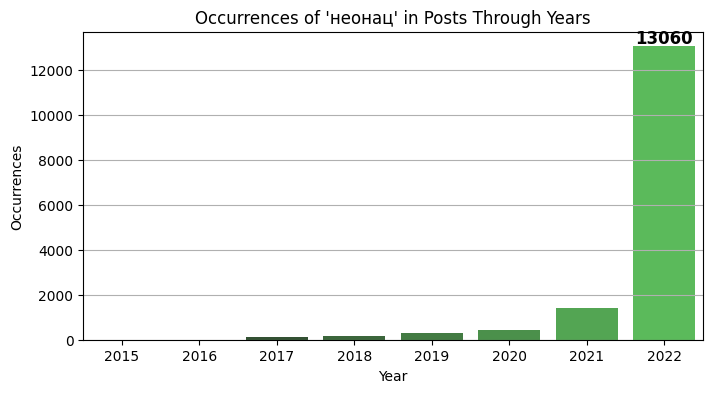

```python
data['date'] = pd.to_datetime(data['date'])
neonaz_posts = data[data['message'].str.contains(
    'неонац', case=False, na=False)].copy()
neonaz_posts.loc[:, 'year'] = neonaz_posts['date'].dt.year
neonaz_count = neonaz_posts['year'].value_counts().sort_index()
neonaz_counts_df = neonaz_count.reset_index()
neonaz_counts_df.columns = ['Year', 'Occurrences']

max_occurrences = neonaz_counts_df['Occurrences'].max()
max_year = neonaz_counts_df[neonaz_counts_df['Occurrences']
                            == max_occurrences]['Year'].values[0]


print("Number of occurrences of 'неонац' for each year:")
for index, row in neonaz_counts_df.iterrows():
    print(f"Year: {row['Year']}, Occurrences: {row['Occurrences']}")

green = (0, 255, 0)
plt.figure(figsize=(8, 4))
sns.barplot(x='Year', y='Occurrences',
            data=neonaz_counts_df, color=adjust_saturation(green, 0.5), hue='Year', legend=False)
plt.text(
    x=neonaz_counts_df['Year'].idxmax(),
    y=max_occurrences * 1.01,
    s=f"{max_occurrences}",
    color="black",
    ha='center',
    fontsize=12,
    fontweight='bold'
)
plt.title("Occurrences of 'неонац' in Posts Through Years")
plt.xlabel("Year")
plt.ylabel("Occurrences")
plt.grid(axis='y')
plt.show()
```

16.4. Show the occurincies of part 'бандер' in posts through years

```
Number of occurrences of 'бандер' for each year:
Year: 2015, Occurrences: 5
Year: 2016, Occurrences: 28
Year: 2017, Occurrences: 206
Year: 2018, Occurrences: 421
Year: 2019, Occurrences: 862
Year: 2020, Occurrences: 1212
Year: 2021, Occurrences: 1818
Year: 2022, Occurrences: 16085
```

[figure not shown]

```python
# plt.yscale('log')  # Set y-axis to logarithmic scale

data['date'] = pd.to_datetime(data['date'])
bander_posts = data[data['message'].str.contains(
    'бандер', case=False, na=False)].copy()
bander_posts.loc[:, 'year'] = bander_posts['date'].dt.year
bander_count = bander_posts['year'].value_counts().sort_index()
bander_counts_df = bander_count.reset_index()
bander_counts_df.columns = ['Year', 'Occurrences']

max_occurrences = bander_counts_df['Occurrences'].max()
max_year = bander_counts_df[bander_counts_df['Occurrences']
                            == max_occurrences]['Year'].values[0]

print("Number of occurrences of 'бандер' for each year:")
for index, row in bander_counts_df.iterrows():
    print(f"Year: {row['Year']}, Occurrences: {row['Occurrences']}")

plt.figure(figsize=(8, 4))
sns.barplot(x='Year', y='Occurrences',
            data=neonaz_counts_df, color=adjust_saturation(green, 0.5), hue='Year', legend=False)
plt.text(
    # x position at the maximum year index
    x=bander_counts_df['Year'].idxmax(),
    y=max_occurrences * 0.82,  # y position slightly above the bar
    s=f"{max_occurrences}",  # Text to display
    color="black",
    ha='center',
    fontsize=12,
    fontweight='bold'
)
plt.title("Occurrences of 'бандер' in Posts Through Years")
plt.xlabel("Year")
plt.ylabel("Occurrences")
plt.grid(axis='y')
plt.show()
```

16.5. Show the occurincies of part 'украи' in posts through years

```
Number of occurrences of 'украи' for each year:
Year: 2015, Occurrences: 214
Year: 2016, Occurrences: 2354
Year: 2017, Occurrences: 10101
Year: 2018, Occurrences: 20237
Year: 2019, Occurrences: 41477
Year: 2020, Occurrences: 42739
Year: 2021, Occurrences: 85640
Year: 2022, Occurrences: 697479
```

[figure not shown]

```python
data['date'] = pd.to_datetime(data['date'])
ukrai_posts = data[data['message'].str.contains(
    'украи', case=False, na=False)].copy()
ukrai_posts.loc[:, 'year'] = ukrai_posts['date'].dt.year
ukrai_count = ukrai_posts['year'].value_counts().sort_index()
ukrai_count_df = ukrai_count.reset_index()
ukrai_count_df.columns = ['Year', 'Occurrences']

max_occurrences = ukrai_count_df['Occurrences'].max()
max_year = ukrai_count_df[ukrai_count_df['Occurrences']
                          == max_occurrences]['Year'].values[0]


print("Number of occurrences of 'украи' for each year:")
for index, row in ukrai_count_df.iterrows():
    print(f"Year: {row['Year']}, Occurrences: {row['Occurrences']}")


cyan = (0, 255, 255)
plt.figure(figsize=(8, 4))
sns.barplot(x='Year', y='Occurrences',
            data=neonaz_counts_df, color=adjust_saturation(cyan, 0.5), hue='Year', legend=False)
plt.text(
    x=bander_counts_df['Year'].idxmax(),
    y=max_occurrences / (12.000 * 4.4),
    s=f"{max_occurrences}",
    color="black",
    ha='center',
    fontsize=12,
    fontweight='bold'
)
plt.title("Occurrences of 'украи' in Posts Through Years")
plt.xlabel("Year")
plt.ylabel("Occurrences")
plt.grid(axis='y')
plt.show()
```

16.6 Depict in circular diagram number of 'укра', 'бандер' and 'неонац' part through all years in posts' text. What is prevailing?

```
Total occurrences of 'Украи': 900241
Total occurrences of 'Бандер': 20637
Total occurrences of 'Неонац': 15513
```

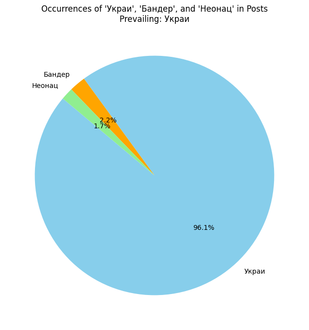

```python
# 16.6 Depict in circular diagram number of 'укра', 'бандер' and 'неонац' part through all years in posts' text. What is prevailing?
ukrai_total = ukrai_count.sum()
bander_total = bander_count.sum()
neonaz_total = neonaz_count.sum()
print(f"Total occurrences of 'Украи': {ukrai_total}")
print(f"Total occurrences of 'Бандер': {bander_total}")
print(f"Total occurrences of 'Неонац': {neonaz_total}")

# Data for the pie chart
labels = ['Украи', 'Бандер', 'Неонац']
values = [ukrai_total, bander_total, neonaz_total]

# Find the prevailing part
prevailing = labels[values.index(max(values))]

# Create a pie chart
plt.figure(figsize=(8, 8))
plt.pie(values, labels=labels, autopct='%1.1f%%', startangle=140,
        colors=['skyblue', 'orange', 'lightgreen'])
plt.title(
    f"Occurrences of 'Украи', 'Бандер', and 'Неонац' in Posts\nPrevailing: {prevailing}")
plt.show()
```

The end of the 5th hw.

17. What's the post, that included "украи" part and got the most views in January each year ? (related to 16th question. Get text, date)

```python
def get_post_with_most_views_in_january_including_ukra(year):
    january_posts = data[(data['date'].dt.year == year)
                         & (data['date'].dt.month == 1)]
    january_posts = january_posts[january_posts['message'].str.contains(
        "украи", case=False, na=False)]

    if january_posts.empty:
        return None

    postID = january_posts['views'].idxmax()
    post = january_posts.loc[postID]

    return post


print("Post with the most views in January including 'украи' part:")
for year in unique_years:
    post = get_post_with_most_views_in_january_including_ukra(year)

    if post is None:
        print(f"No posts including 'украи' in January {year}")

    else:
        postDate = post['date']
        postViews = post['views']
        # Truncate the message if it exceeds 120 characters
        truncated_message = post['message'][:120] + \
            "..." if len(post['message']) > 100 else post['message']
        print(f"YEAR: {make_bold(year)}, DATE: {
              make_bold(postDate)}, VIEWS: {make_bold(postViews)}")
        print(f"MESSAGE: {truncated_message}")
    print("-" * 50)
```

```
Post with the most views in January including 'украи' part:
YEAR: 2022, DATE: 2022-01-17 07:45:19+00:00, VIEWS: 467168.0
MESSAGE: Экс-президент Украины Пётр Порошенко прилетел в Киев. В 11:00 (12:00 по Мск) его ждёт суд по избранию меры пресечения по...
--------------------------------------------------
YEAR: 2021, DATE: 2021-01-24 13:21:54+00:00, VIEWS: 486278.0
MESSAGE: И ещё про тик-ток. Среди прочих в рекомендации выходят аккаунты пользователей Украины, рассказывающие, как правильно про...
--------------------------------------------------
YEAR: 2020, DATE: 2020-01-08 03:55:35+00:00, VIEWS: 914017.0
MESSAGE: Момент падения самолёта "Украинских авиалиний" под Тегераном. Видео опубликовали очевидцы, по их словам, на видео — тот ...
--------------------------------------------------
YEAR: 2019, DATE: 2019-01-07 13:22:45+00:00, VIEWS: 244743.0
MESSAGE: Видео спасения 7 членов экипажа "Волго-Балта"

Судно вышло из азовского порта под панамским флагом, везло уголь в Самсу...
--------------------------------------------------
YEAR: 2018, DATE: 2018-01-12 19:43:09+00:00, VIEWS: 207556.0
MESSAGE: К вопросу «умеет ли Путин вести публичную дискуссию?»: выпад украинского посла на саммите СНГ и реакция Путина...
--------------------------------------------------
YEAR: 2017, DATE: 2017-01-23 13:41:43+00:00, VIEWS: 224905.0
MESSAGE: Украинская оценка бронетехники армии ДНР и ЛНР
В взято у украинского блоггера feldherrnhalle

В данном материале будет ...
--------------------------------------------------
YEAR: 2016, DATE: 2016-01-20 06:08:17+00:00, VIEWS: 2163.0
MESSAGE: Доброе утро!

Вот главные новости к этому часу:

Эксперты из Bank of America рассчитали российский бюджет при долларе за...
--------------------------------------------------
No posts including 'украи' in January 2015
--------------------------------------------------
```

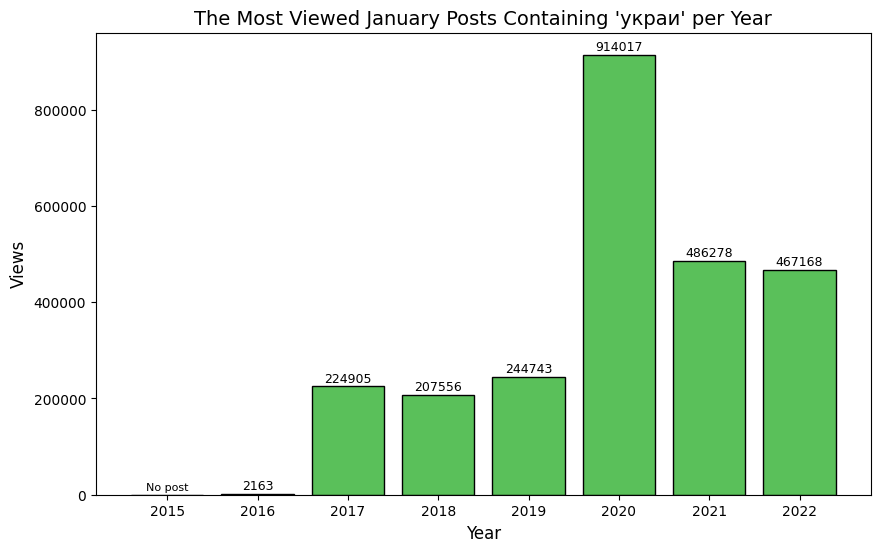

```
The post with the most views in January 2020 including 'украи' is:
DATE: 2020-01-08 03:55:35+00:00
VIEWS: 914017.0
MESSAGE: Момент падения самолёта "Украинских авиалиний" под Тегераном. Видео опубликовали очевидцы, по их словам, на видео — тот самый Boeing 737.

The post with the most views including 'украи' across all time is:
DATE: 2022-07-27 15:29:58+00:00
VIEWS: 4966552.0
MESSAGE: В пострадавшем от психотропных веществ мозгу президента Украины возникала следующая картинка светлого будущего его страны (рис. 1).
Западные аналитики считают, что на самом деле будет так (рис. 2).
```

```python
def get_post_with_most_views_including_ukra_all_time():
    posts_with_ukra = data[data['message'].str.contains(
        "украи", case=False, na=False)]
    if posts_with_ukra.empty:
        return None
    return posts_with_ukra.loc[posts_with_ukra['views'].idxmax()]

# Function to find the most viewed January post containing "украи" for a given year


def get_post_with_most_views_in_january_including_ukra(year):
    jan_posts = data[(data['date'].dt.year == year)
                     & (data['date'].dt.month == 1)]
    posts_with_ukra = jan_posts[jan_posts['message'].str.contains(
        "украи", case=False, na=False)]
    if posts_with_ukra.empty:
        return None
    return posts_with_ukra.loc[posts_with_ukra['views'].idxmax()]


# VISUALIZATION
years = []
views = []
messages = []

# Get unique years from the data if not already defined
unique_years = data['date'].dt.year.unique()

# Loop through each year to get the post with the most views in January
for year in sorted(unique_years):
    post = get_post_with_most_views_in_january_including_ukra(year)
    if post is not None:
        years.append(year)
        views.append(post['views'])
        # Truncate message for display purposes
        messages.append(
            post['message'][:100] + "..." if len(post['message']) > 100 else post['message'])
    else:
        years.append(year)
        views.append(0)  # Zero views for years without relevant posts
        messages.append("No post")

green = (0, 255, 0)
# Create a bar chart
plt.figure(figsize=(10, 6))
bars = plt.bar(years, views, color=adjust_saturation(
    green, 0.4), edgecolor="black")

plt.title("The Most Viewed January Posts Containing 'украи' per Year", fontsize=14)
plt.xlabel("Year", fontsize=12)
plt.ylabel("Views", fontsize=12)

# Annotate bars with views or "No post"
for bar, msg, view in zip(bars, messages, views):
    if view != 0:
        plt.text(bar.get_x() + bar.get_width() / 2,
                 bar.get_height() + max(views)*0.01, f"{view:.0f}", ha='center', fontsize=9)
    else:
        plt.text(bar.get_x() + bar.get_width() / 2, bar.get_height() + max(views)*0.01,
                 msg, ha='center', fontsize=8, color='black')

plt.xticks(years, fontsize=10)
plt.show()

# Show the message of the most-viewed post in January 2020
mostViewedPost_2020 = get_post_with_most_views_in_january_including_ukra(2020)
if mostViewedPost_2020 is not None:
    print("The post with the most views in January 2020 including 'украи' is:")
    print(f"DATE: {mostViewedPost_2020['date']}")
    print(f"VIEWS: {mostViewedPost_2020['views']}")
    print(f"MESSAGE: {mostViewedPost_2020['message']}")
else:
    print("No posts including 'украи' found in January 2020.")

# Find and print the post including "украи" with the most views across all time
mostViewedPost_all_time = get_post_with_most_views_including_ukra_all_time()
if mostViewedPost_all_time is not None:
    print("\nThe post with the most views including 'украи' across all time is:")
    print(f"DATE: {mostViewedPost_all_time['date']}")
    print(f"VIEWS: {mostViewedPost_all_time['views']}")
    print(f"MESSAGE: {mostViewedPost_all_time['message']}")
else:
    print("No posts including 'украи' found in the dataset.")
```

18.0 What're the posts containing "украи" part and got the most views each month by year ? (related to 16th question. Get text, date)

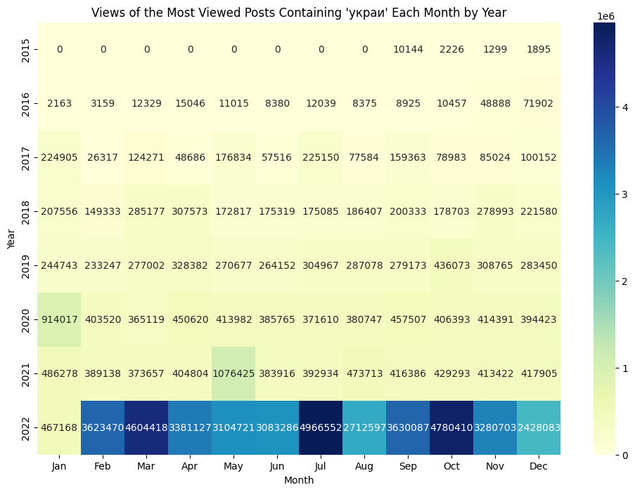

```python
def get_post_with_most_views_including_ukra_by_month(year, month):
    posts_in_month = data[(data['date'].dt.year == year)
                          & (data['date'].dt.month == month)]
    posts_with_ukra = posts_in_month[posts_in_month['message'].str.contains(
        "украи", case=False, na=False)]
    if posts_with_ukra.empty:
        return None
    else:
        return posts_with_ukra.loc[posts_with_ukra['views'].idxmax()]


# Get unique years
unique_years = sorted(data['date'].dt.year.unique())

# Initialize a list to collect records
records = []

# Loop through each year and month to get the posts
for year in unique_years:
    for month in range(1, 13):
        post = get_post_with_most_views_including_ukra_by_month(year, month)
        if post is not None:
            records.append({
                'year': year,
                'month': month,
                'date': post['date'],
                'views': post['views'],
                'message': post['message']
            })
        else:
            # No post for this month
            records.append({
                'year': year,
                'month': month,
                'date': None,
                'views': 0,
                'message': 'No post'
            })

# Create a DataFrame from the records
df_posts = pd.DataFrame(records)

# Pivot the DataFrame to create a heatmap-friendly format for views
pivot_views = df_posts.pivot(
    index='year', columns='month', values='views').fillna(0)

# Set month names for better readability
month_names = ['Jan', 'Feb', 'Mar', 'Apr', 'May', 'Jun',
               'Jul', 'Aug', 'Sep', 'Oct', 'Nov', 'Dec']
pivot_views.columns = month_names

# Visualize the views using a heatmap
plt.figure(figsize=(12, 8))
sns.heatmap(pivot_views, annot=True, fmt=".0f", cmap="YlGnBu", cbar=True)
plt.title("Views of the Most Viewed Posts Containing 'украи' Each Month by Year")
plt.xlabel("Month")
plt.ylabel("Year")
plt.show()
```

18. How many posts included "украи" part every month through each year?

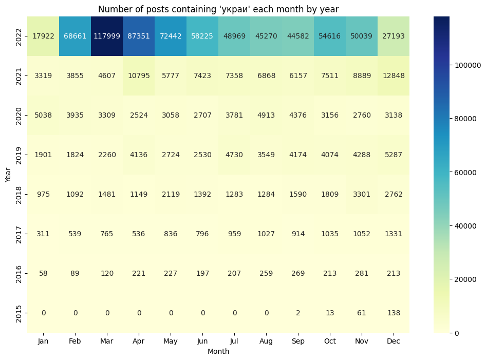

```python
data['date'] = pd.to_datetime(data['date'])


def count_posts_including_ukra_by_month(year):
    year_posts = data[data['date'].dt.year == year]
    monthly_counts = (
        year_posts[year_posts['message'].str.contains(
            "украи", case=False, na=False)]
        .groupby(year_posts['date'].dt.month)
        .size()
    )

    # Fill in missing months with 0
    monthly_counts = monthly_counts.reindex(range(1, 13), fill_value=0)

    return monthly_counts


unique_years = data['date'].dt.year.unique()


# VISUALIZATION
monthly_counts_df = pd.DataFrame()

for year in unique_years:
    counts = count_posts_including_ukra_by_month(year)
    monthly_counts_df[year] = counts

monthly_counts_df = monthly_counts_df.T
monthly_counts_df.columns = [
    'Jan', 'Feb', 'Mar', 'Apr', 'May', 'Jun', 'Jul', 'Aug', 'Sep', 'Oct', 'Nov', 'Dec']

plt.figure(figsize=(12, 8))
sns.heatmap(monthly_counts_df, annot=True, fmt="d", cmap="YlGnBu", cbar=True)
plt.title("Number of posts containing 'украи' each month by year")
plt.xlabel("Month")
plt.ylabel("Year")
plt.show()
```

19. What time of day (morning, afternoon, evening, night) has the highest average views?

```
Time of day with the highest average views: Night, hour range: 0 - 5.

 Average views: date
0    61158.075206
1    51325.247103
2    51974.112625
3    57565.150660
Name: views, dtype: float64

Where: 0 - Night, 1 - Morning, 2 - Afternoon, 3 - Evening
```

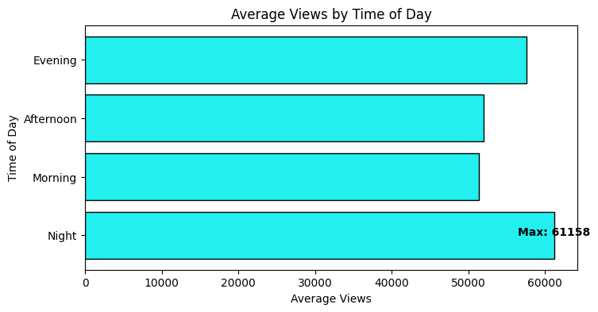

```python
data['date'] = pd.to_datetime(data['date'])
data['views'] = pd.to_numeric(data['views'], errors='coerce')

# Drop rows with NaN in 'views'
data = data.dropna(subset=['views'])

time_labels = {0: "Night", 1: "Morning", 2: "Afternoon", 3: "Evening"}


# Group by time of day (0: Night, 1: Morning, 2: Afternoon, 3: Evening) and calculate average views
timeViews_group = data.groupby(data['date'].dt.hour // 6)['views'].mean()

timeForMostViews = timeViews_group.idxmax()

# find range of hours for timeForMostViews
time_group = f"{timeForMostViews * 6} - {timeForMostViews * 6 + 5}"

mostViewedTimeLabel = time_labels[timeForMostViews]

print(f"Time of day with the highest average views: {
      make_bold(mostViewedTimeLabel)}, hour range: {make_bold(time_group)}.")
print(f"\n Average views: {timeViews_group}")
print("\nWhere: 0 - Night, 1 - Morning, 2 - Afternoon, 3 - Evening")

# VISUALIZATION
data['date'] = pd.to_datetime(data['date'])
data['views'] = pd.to_numeric(data['views'], errors='coerce')
data = data.dropna(subset=['views'])

time_labels = {0: "Night", 1: "Morning", 2: "Afternoon", 3: "Evening"}

timeViews_group = data.groupby(data['date'].dt.hour // 6)['views'].mean()

mapped_time_labels = timeViews_group.index.map(time_labels)


# Plotting the horizontal bar chart
plt.figure(figsize=(8, 4))
plt.barh(mapped_time_labels, timeViews_group.values,
         color=adjust_saturation(cyan, 0.8), edgecolor="black")
plt.xlabel("Average Views")
plt.ylabel("Time of Day")
plt.title("Average Views by Time of Day")

plt.text(timeViews_group.max(), mostViewedTimeLabel, f"Max: {
         timeViews_group.max():.0f}", ha='center', color='black', weight='bold')

plt.show()
```

20. Which day of the week has the highest average views per post?

```
Day of the week with the highest average views per post: Sunday

 Average views: date
0    53719.046216
1    51869.867490
2    51559.293707
3    51418.007248
4    52444.799442
5    56355.270455
6    56720.058395
Name: views, dtype: float64

Where: 0 - Monday, 1 - Tuesday, 2 - Wednesday, 3 - Thursday, 4 - Friday, 5 - Saturday, 6 - Sunday
```

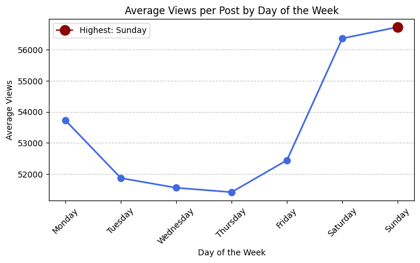

```python
data['date'] = pd.to_datetime(data['date'])
data['views'] = pd.to_numeric(data['views'], errors='coerce')
data = data.dropna(subset=['views'])

day_labels = {0: "Monday", 1: "Tuesday", 2: "Wednesday", 3: "Thursday",
              4: "Friday", 5: "Saturday", 6: "Sunday"}

dayInWeekWithAvViews = data.groupby(data['date'].dt.dayofweek)[
    'views'].mean()

dayInWeekWithMostViews = dayInWeekWithAvViews.idxmax()
mostViewedDayLabel = day_labels[dayInWeekWithMostViews]


print(f"Day of the week with the highest average views per post: {
      make_bold(mostViewedDayLabel)}")
print(f"\n Average views: {dayInWeekWithAvViews}")
print("\nWhere: 0 - Monday, 1 - Tuesday, 2 - Wednesday, 3 - Thursday, 4 - Friday, 5 - Saturday, 6 - Sunday")

# VISAULIZATION

data['date'] = pd.to_datetime(data['date'])
data['views'] = pd.to_numeric(data['views'], errors='coerce')
data = data.dropna(subset=['views'])

# Calculate the average views per day of the week
day_labels = {0: "Monday", 1: "Tuesday", 2: "Wednesday", 3: "Thursday",
              4: "Friday", 5: "Saturday", 6: "Sunday"}
dayInWeekWithAvViews = data.groupby(data['date'].dt.dayofweek)['views'].mean()
dayInWeekWithAvViews.index = dayInWeekWithAvViews.index.map(day_labels)

# Prepare the line plot with markers
plt.figure(figsize=(8, 4))
plt.plot(dayInWeekWithAvViews.index, dayInWeekWithAvViews.values,
         marker='o', color='royalblue', linestyle='-', linewidth=2, markersize=8)

# Highlight the maximum average views day
max_views_day = dayInWeekWithAvViews.idxmax()
max_views_value = dayInWeekWithAvViews.max()
plt.plot(max_views_day, max_views_value, marker='o', color='darkred',
         markersize=12, label=f"Highest: {max_views_day}")

plt.xlabel("Day of the Week")
plt.ylabel("Average Views")
plt.title("Average Views per Post by Day of the Week")
plt.xticks(rotation=45)
plt.legend()
plt.grid(axis='y', linestyle='--', alpha=0.7)

plt.show()
```

21. What's the views number for all sensitive topics?

```python
viewsNumberPerTopic = data.groupby('sensitive-topic')['views'].sum()
viewsNumberPerTopic = viewsNumberPerTopic.sort_values(ascending=False)

# Format views to be more readable
viewsNumberPerTopic = viewsNumberPerTopic.apply(
    lambda x: f"{x:,.0f}".replace(",", " "))


print("Number of topics:", data['sensitive-topic'].nunique())
print("Views number for all sensitive topics:")
print(viewsNumberPerTopic)
```

```
Number of topics: 69
Views number for all sensitive topics:
sensitive-topic
none                                          154 754 046 367
politics                                       88 985 514 166
politics,racism                                30 477 984 570
weapons,politics                               22 992 424 291
weapons                                        20 641 781 091
                                                   ...
suicide,health_shaming                                 31 417
pornography,politics,sexual_minorities                 15 155
drugs,prostitution                                     11 751
body_shaming,racism                                     7 452
terrorism,politics,racism,social_injustice              4 864
Name: views, Length: 69, dtype: object
```

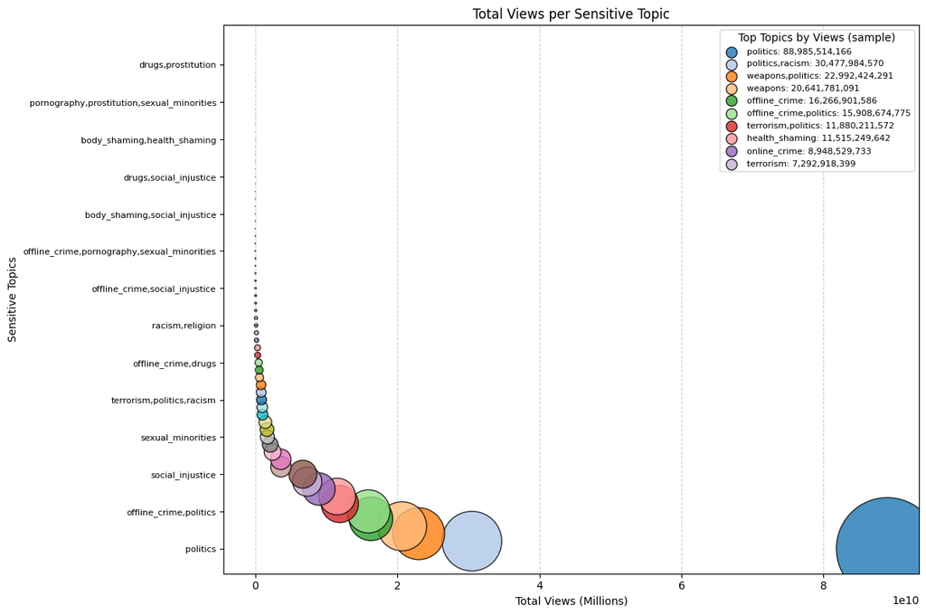

```python
viewsNumberPerTopic = data.groupby('sensitive-topic')['views'].sum()

viewsNumberPerTopic = viewsNumberPerTopic.sort_values(ascending=False)

if 'none' in viewsNumberPerTopic.index:
    viewsNumberPerTopic = viewsNumberPerTopic.drop('none')

plt.figure(figsize=(12, 8))

colors = sns.color_palette("tab20", len(viewsNumberPerTopic))

plt.scatter(
    viewsNumberPerTopic.values,
    np.arange(len(viewsNumberPerTopic)),
    s=viewsNumberPerTopic.values / 1e7,  # Adjust size for readability
    c=colors,
    alpha=0.8,
    edgecolor="black"
)

plt.xlabel("Total Views (Millions)")
plt.ylabel("Sensitive Topics")
plt.title("Total Views per Sensitive Topic")

n = 5  # Show every 5th label
plt.yticks(
    np.arange(len(viewsNumberPerTopic))[::n],
    viewsNumberPerTopic.index[::n],
    fontsize=8
)

legend_labels = [
    f"{topic}: {viewsNumberPerTopic[topic]:,.0f}" for topic in viewsNumberPerTopic.index[:10]
]
for i, label in enumerate(legend_labels):
    plt.scatter([], [], c=[colors[i]], alpha=0.8,
                s=100, edgecolor="black", label=label)

plt.legend(loc="upper right", title="Top Topics by Views (sample)", fontsize=8)

plt.grid(axis='x', linestyle='--', alpha=0.6)
plt.tight_layout()
plt.show()
```

22. Which posts with different sensitive topics receive the highest average views number?

```
Avarage views number for all sensitive topics:
sensitive-topic
health_shaming,politics                           122 177
terrorism,politics,racism                         103 012
weapons,politics                                   98 400
terrorism,politics                                 86 129
offline_crime,politics,racism,social_injustice     72 929
                                                   ...
suicide,health_shaming                              7 854
body_shaming,racism                                 7 452
terrorism,politics,racism,social_injustice          4 864
drugs,prostitution                                  3 917
pornography,politics,sexual_minorities              3 789
Name: views, Length: 69, dtype: object
```

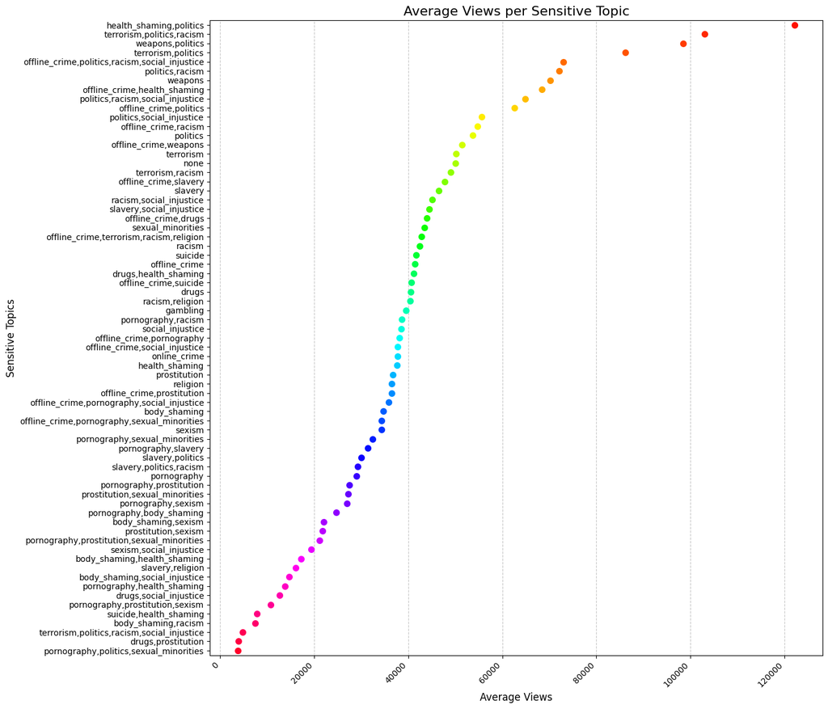

```python
averageViewsPerTopic = data.groupby('sensitive-topic')['views'].mean()
averageViewsPerTopicSorted = averageViewsPerTopic.sort_values(ascending=False)

# Format views to be more readable
avViewsNumberPerTopic = averageViewsPerTopicSorted.apply(
    lambda x: f"{x:,.0f}".replace(",", " "))


print(f"Avarage views number for all sensitive topics: \n{
      avViewsNumberPerTopic}")

# VISUALIZATION
averageViewsPerTopic = data.groupby('sensitive-topic')['views'].mean()
averageViewsPerTopicSorted = averageViewsPerTopic.sort_values(ascending=False)

plt.figure(figsize=(14, 12))
colors = sns.color_palette("hsv", len(averageViewsPerTopicSorted))

sns.stripplot(
    x=averageViewsPerTopicSorted.values,
    y=averageViewsPerTopicSorted.index,
    palette=colors,
    size=8,
    marker='o'
)

plt.xlabel("Average Views", fontsize=12)
plt.ylabel("Sensitive Topics", fontsize=12)
plt.title("Average Views per Sensitive Topic", fontsize=16)

plt.xticks(rotation=45, ha='right', fontsize=10)
plt.grid(axis='x', linestyle='--', alpha=0.7)

plt.tight_layout()
plt.show()
```

23. What's the message of post, that was forwarded from another channels the most, about?

```python
data['date'] = pd.to_datetime(data['date'])

most_forwarded_from_id = data['_from_id'].value_counts().idxmax()
most_forwarded_post = data[data['_from_id'] == most_forwarded_from_id].iloc[0]
repostPostNum = data[data['_from_id'] == most_forwarded_from_id].shape[0]


forwardedPostId = most_forwarded_post['id']
forwardedPostText = most_forwarded_post['message']
forwardedPostDate = most_forwarded_post['date']

print(f"The message of the post that was forwarded from another channel the most is:")
print(f"{forwardedPostText}")
print(f"Date: {make_bold(forwardedPostDate)}, ID: {
      make_bold(forwardedPostId)}.")
print(f"It was reposted : {make_bold(repostPostNum)} times")
```

```
The message of the post that was forwarded from another channel the most is:
❗️Дорогие друзья, напоминаем, что у нас нет АБСОЛЮТНО НИКАКИХ иных проектов. Ни региональных, ни тематических,  НИ в ДРУГИХ СОЦСЕТЯХ.

И если вы видите нашу аватарку и название Раньше всех с какой-то другой приставкой, знайте, отношения к нам это решительно не имеет.

ВАЖНО: в последнее время появилось немало людей, которые просто взяли нашу аватарку и создают от нашего имени каналы — ВНИМАТЕЛЬНО ЧИТАЙТЕ АДРЕС — НАШ ТОЛЬКО ЭТОТ —  t.me/bbbreaking, в адресе нашего, оригинального канала «Раньше всех Ну почти» нет ни цифр, ни дополнительных слов или букв. К  размещё…
Date: 2022-03-17 17:35:56+00:00, ID: 119919.0.
It was reposted : 52389 times
```

24. What were the messages of posts (each year), that was forwarded from another channels the most, about? (return post id, message, date)

```python
data['date'] = pd.to_datetime(data['date'])
data['year'] = data['date'].dt.year

most_forwarded_posts = []
for year, group in data.groupby('year'):
    most_forwarded_from_id = group['_from_id'].value_counts().idxmax()
    most_forwarded_post = group[group['_from_id']
                                == most_forwarded_from_id].iloc[0]

    post_info = {
        "year": year,
        "post_id": most_forwarded_post['id'],
        "message": most_forwarded_post['message'],
        "date": most_forwarded_post['date'],
        "_from_id": most_forwarded_from_id
    }
    most_forwarded_posts.append(post_info)


print("The messages of the posts that were forwarded from another channels the most each year are:")
for post in most_forwarded_posts:
    print(f"Year: {make_bold(post['year'])}, Post ID: {
        post['post_id']}, Date: {make_bold(post['date'])}\n")
    print(f"Message: {post['message']}")
    print("-" * 50)
```

```
The messages of the posts that were forwarded from another channels the most each year are:
Year: 2015, Post ID: 55.0, Date: 2015-10-27 20:22:23+00:00

Message: У нас тут репортаж из чеченской фотостудии Сайда-Али Муцаева, который делает землякам кровавые "луки" с автоматами, ножами, убийствами и ограблениями на фоне гор

http://varlamov.moslenta.ru/article/2015/10/26/chechnya/
--------------------------------------------------
Year: 2016, Post ID: 9222.0, Date: 2016-12-30 00:05:58+00:00

Message: Кстати, похож на черного Сквирского. Я одна заметила?
--------------------------------------------------
Year: 2017, Post ID: 6133.0, Date: 2017-11-24 10:50:50+00:00

Message: Я бы не стал репостить этот текст, поскольку не разделяю ветхозаветного принципа "око за око". Что, впрочем, общеизвестно.

Но я сделаю репост, потому что этот текст был дважды забанен на Фейсбуке, хотя ничего, что стоило бы банить, в нем нет. Бороться с Фейскомнадзором - святая обязанность каждого честного человека.

https://t.me/karaulny/32414
--------------------------------------------------
Year: 2018, Post ID: 11718.0, Date: 2018-12-24 10:44:38+00:00

Message: Прикиньте как от этого видоса сейчас РВАНЕТ в штатах)))??????
@go338
--------------------------------------------------
Year: 2019, Post ID: 22807.0, Date: 2019-09-20 10:06:53+00:00

Message: ⚡️Павла Устинова отпустили под подписку о невыезде
--------------------------------------------------
Year: 2020, Post ID: 55882.0, Date: 2020-07-07 18:51:50+00:00

Message: ⚡️Суд арестовал Ивана Сафронова на два месяца до 6 сентября — решение
--------------------------------------------------
Year: 2021, Post ID: 27460.0, Date: 2021-12-26 08:50:42+00:00

Message: nan
--------------------------------------------------
Year: 2022, Post ID: 119919.0, Date: 2022-03-17 17:35:56+00:00

Message: ❗️Дорогие друзья, напоминаем, что у нас нет АБСОЛЮТНО НИКАКИХ иных проектов. Ни региональных, ни тематических,  НИ в ДРУГИХ СОЦСЕТЯХ.

И если вы видите нашу аватарку и название Раньше всех с какой-то другой приставкой, знайте, отношения к нам это решительно не имеет.

ВАЖНО: в последнее время появилось немало людей, которые просто взяли нашу аватарку и создают от нашего имени каналы — ВНИМАТЕЛЬНО ЧИТАЙТЕ АДРЕС — НАШ ТОЛЬКО ЭТОТ —  t.me/bbbreaking, в адресе нашего, оригинального канала «Раньше всех Ну почти» нет ни цифр, ни дополнительных слов или букв. К  размещё…
--------------------------------------------------
```

25. Which topics (from sensitive-topic) are most associated with toxic toxicity posts?

```
The topics that are most associated with toxic toxicity posts are:
sensitive-topic
politics                                      140736
politics,racism                                97574
offline_crime                                  46432
weapons,politics                               38109
terrorism,politics                             36097
                                               ...
offline_crime,terrorism,racism,religion            2
pornography,slavery                                1
offline_crime,pornography,social_injustice         1
slavery,religion                                   1
body_shaming,racism                                1
Name: count, Length: 67, dtype: int64
```

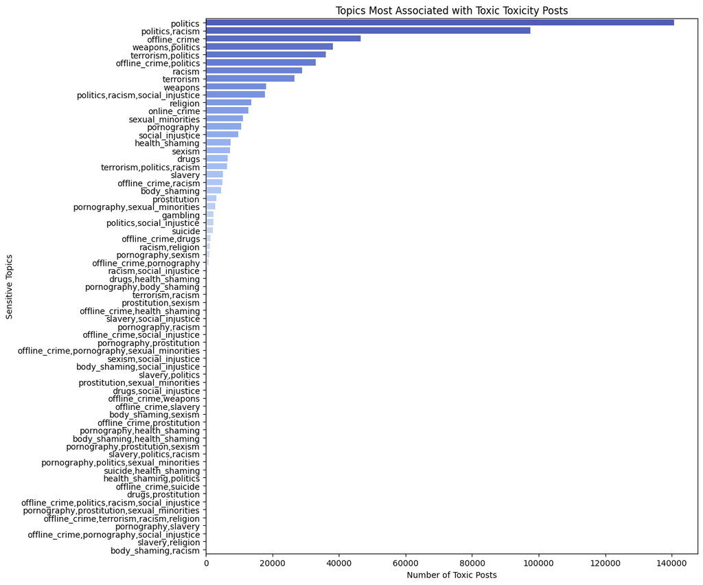

```python
# find all topics that have toxic toxicity

toxicTopics = data[data['toxicity'] ==
                   'toxic']['sensitive-topic'].value_counts()

if 'none' in toxicTopics.index:
    toxicTopics = toxicTopics.drop('none')

print("The topics that are most associated with toxic toxicity posts are:")
print(f"{toxicTopics}")

plt.figure(figsize=(12, 10))
sns.barplot(x=toxicTopics.values, y=toxicTopics.index, palette="coolwarm")
plt.title("Topics Most Associated with Toxic Toxicity Posts")
plt.xlabel("Number of Toxic Posts")
plt.ylabel("Sensitive Topics")

# Show the plot
plt.tight_layout()
plt.show()
```

```python
data['date'] = pd.to_datetime(data['date'])

mostViewedPostFebrId = data[data['date'].dt.month == 2]['views'].idxmax()
mostViewedPostFebrText = data.loc[mostViewedPostFebrId, 'message']
mostViewedPostFebrViews = data.loc[mostViewedPostFebrId, 'views']
mostViewedPostFebrDate = data.loc[mostViewedPostFebrId, 'date']

print(f"The most viewed post for February in 2022: \nDATE: {make_bold(
    mostViewedPostFebrDate)}, ID: is: {make_bold(mostViewedPostFebrId)}")
print(f"Text: {mostViewedPostFebrText}")
print(f"Views: {make_bold(mostViewedPostFebrViews)}")
```

```
The most viewed post for February in 2022:
DATE: 2022-02-28 12:03:51+00:00, ID: is: 5520565
Text: 6. Путин утверждает, что основные столкновения России – не с регулярной украинской армией, а с отрядами неонацистов и бандеровцев, и вот от этого ушам, конечно, больнее всего. Ладно, что неонацисты выполняют приказания главнокомандующего-еврея. Ладно, что в числе тех, кто этому главнокомандующ…

Любой, кому люди еще нужны, кто общается со своими друзьями и родными в Украине, в курсе: обороняться там вышли примерно все.

В том числе те, для кого Бандера совсем не герой и кто каждое 9 мая встречает с той же горечью и теплотой, как это делают в Петербурге, Волгограде и Москве. Эти люди – граждане современной Украины, которые защищают свой дом.

7. Не знаю, есть ли еще люди, которые имеют на Путина хоть какое-то влияние, но, допустим, есть. Не знаю, как они сейчас засыпают и просыпаются и что тренируют между пробуждением и сном. Но всем им – от Ротенбергов до Тимченко, от Чемезова до Грефа, от Абрамовича до Мордашова, от Кудрина до Эрнста –…

8. Финальное и главное: эта война должна быть немедленно закончена.
Views: 3623470.0
```